# Founders Cocaine Sensitivity Data: Heritability and Plotting

Michael C. Saul (michael.saul [at] jax.org)

# 1 Background

## 1.1 Motivation

### 1.1.1 Purpose of analysis

This analysis is performed to process the cocaine sensitization data and calculate:

1. Heritability
2. Strain-by-sex means and standard errors for plotting

**These data were collected by the CSNA staff.** The preprocessing script `sensi_import_preprocess.Rmd` was used to filter the data to only those data requiring reporting.

# 2 Analysis

## 2.1 Setup

### 2.1.1 Working directory

All chunks will run in the working folder for this experiment.

```r
script_root_dir = "~/Downloads/founders_heritability/"
knitr::opts_knit$set(root.dir = script_root_dir)
```

Getting current date

```r
current_date = format(Sys.time(),"%Y-%m-%d")
```

### 2.1.2 R libraries

Calling R libraries necessary for this analysis.

```r
library("tidyverse")
```

```r
library("lubridate")
library("cowplot")
library("MASS")
library("ggbeeswarm")
```

### 2.1.3 Getting `norm_rank_transform` function

```r
norm_rank_transform = function(x, c = (0)) {
  stopifnot(is.numeric(x) & is.vector(x))
  N = length(x)
  return(qnorm((rank(x) - c) / (N - (2 * c) + 1)))
}
```

## 2.2 Importing data

## 2.3 Importing and displaying raw sensitivity data

Getting data from the filtering script.

```r
sensi_data = readRDS(paste(script_root_dir, "data/sensi_data_preprocessed_2019-10-08.RDS", sep = ""))
```

Displaying raw data.

```r
sensi_data  = sensi_data[which(!is.na(sensi_data$Sensi)),]
sensi_data
```

|  | Subject_ID | Strain | Sex | Comment | Study | DOB_Year | DOB_Month | DOB_Day | Day1_Start_Year | Day1_Start_Month | Day1_Start_Day | Day19_End_Year | Day19_End_Month | Day19_End_Day | Data_Received_Year | Data_Received_Month | Data_Received_Day | Sensi |
| --- | --- | --- | --- | --- | --- | --- | --- | --- | --- | --- | --- | --- | --- | --- | --- | --- | --- | --- |
| 11268 | 11268 | 129S1/SvImJ | F | Complete Data | SENS-COCA | 2017 | 5 | 23 | 2017 | 7 | 24 | 2017 | 8 | 11 | 2018 | 12 | 5 | 0.00000 |
| 11269 | 11269 | 129S1/SvImJ | F | Complete Data | SENS-COCA | 2017 | 5 | 23 | 2017 | 7 | 24 | 2017 | 8 | 11 | 2018 | 12 | 5 | 0.00000 |
| 11270 | 11270 | 129S1/SvImJ | F | SS flagged D19- high for that mouse but not impossible and there is a male COC close to this on D19- final keep D19 not an outlier | SENS-COCA | 2017 | 5 | 23 | 2017 | 7 | 24 | 2017 | 8 | 11 | 2018 | 12 | 5 | 201.19849 |
| 11497 | 11497 | 129S1/SvImJ | F | Complete Data | SENS-COCA | 2017 | 7 | 23 | 2017 | 9 | 18 | 2017 | 10 | 6 | 2018 | 12 | 5 | 77.06642 |
| A1597 | A1597 | 129S1/SvImJ | F | Complete Data | SENS-COCA | 2017 | 11 | 21 | 2018 | 1 | 29 | 2018 | 2 | 16 | 2018 | 12 | 5 | -12.70000 |
| 11272 | 11272 | 129S1/SvImJ | M | Complete Data | SENS-COCA | 2017 | 5 | 23 | 2017 | 7 | 24 | 2017 | 8 | 11 | 2018 | 12 | 5 | 1421.96274 |
| 11274 | 11274 | 129S1/SvImJ | M | Complete Data | SENS-COCA | 2017 | 5 | 23 | 2017 | 7 | 24 | 2017 | 8 | 11 | 2018 | 12 | 5 | 1398.96538 |
| 11276 | 11276 | 129S1/SvImJ | M | Complete Data | SENS-COCA | 2017 | 5 | 23 | 2017 | 7 | 24 | 2017 | 8 | 11 | 2018 | 12 | 5 | -80.82525 |
| 11500 | 11500 | 129S1/SvImJ | M | Complete Data | SENS-COCA | 2017 | 7 | 23 | 2017 | 9 | 18 | 2017 | 10 | 6 | 2018 | 12 | 5 | 1209.92012 |
| A1600 | A1600 | 129S1/SvImJ | M | Complete Data | SENS-COCA | 2017 | 11 | 21 | 2018 | 1 | 29 | 2018 | 2 | 16 | 2018 | 12 | 5 | 5621.54522 |

[output cut: 218 more lines]

Getting founders strain key

```r
founders_key = readRDS("~/Desktop/cc_do_founders_key.RDS")
row.names(founders_key) = founders_key$strain
```

### 2.3.1 Fitting ANOVA model for sensitization data

Looking at the residuals of the simplest model first.

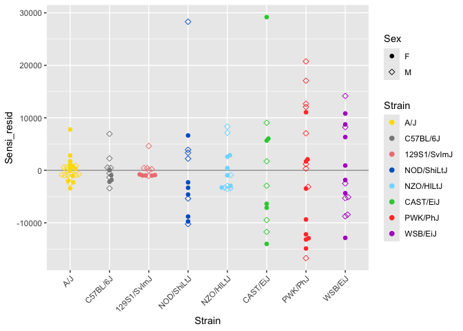

```r
sensi_resid = sensi_data
sensi_resid = sensi_resid[which(sensi_resid$Study == "SENS-COCA"),]
sensi_resid$Sensi_resid = resid(lm(Sensi ~ Strain, data = sensi_resid))
sensi_resid$Strain = factor(sensi_resid$Strain,
                            levels = founders_key$strain,
                            ordered = TRUE)

ggplot(data = sensi_resid, aes(x = Strain, y = Sensi_resid, color = Strain, shape = Sex)) +
  geom_hline(yintercept = 0, col = "#999999") +
  geom_beeswarm(size = 2) +
  scale_color_manual(values = founders_key$collaborative_cross_color_broman) +
  theme(axis.text.x = element_text(angle = 45, hjust = 1)) +
  scale_shape_manual(values = c(16,23))
```

These residuals look good, but with some heteroscedasticity. The data may benefit from a transformation.

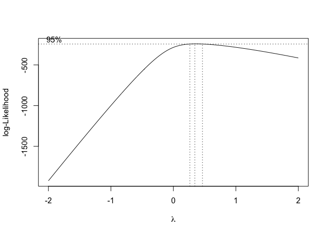

```r
transform_factor = abs(min(sensi_resid[,"Sensi"])) + 1
sensi_resid$Sensi_plus = sensi_resid$Sensi + transform_factor
boxcox(lm(Sensi_plus ~ Strain, data = sensi_resid[which(sensi_resid$Study == "SENS-COCA"),]))
```

The Box-Cox centers around 1/3, which indicates that a cube root transformation may be advantageous.

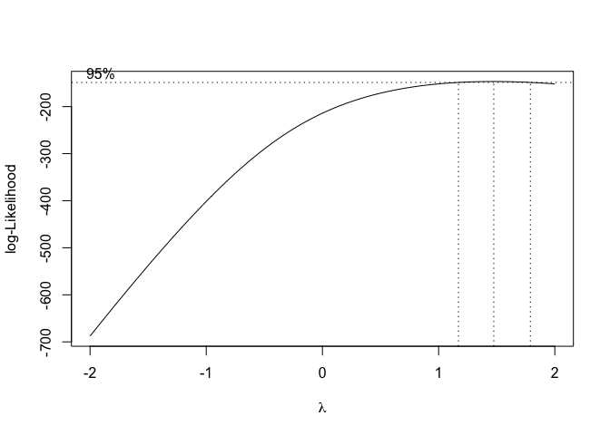

```r
cubert = function(x) {
  return(sign(x) * (abs(x) ^ (1/3)))
}
transform_factor = abs(cubert(min(sensi_resid$Sensi))) + 1
sensi_resid$Sensi_cubert = cubert(sensi_resid$Sensi) + transform_factor
boxcox(lm(Sensi_cubert ~ Strain, data = sensi_resid[which(sensi_resid$Study == "SENS-COCA"),]))
```

This centers closer to 1.5, but with a very broad confidence interval. Looking at the residuals.

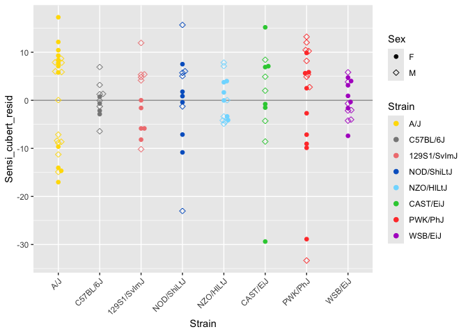

```r
sensi_resid$Sensi_cubert_resid = resid(lm(Sensi_cubert ~ Strain, data = sensi_resid))

ggplot(data = sensi_resid, aes(x = Strain, y = Sensi_cubert_resid, color = Strain, shape = Sex)) +
  geom_hline(yintercept = 0, col = "#999999") +
  geom_beeswarm(size = 2) +
  scale_color_manual(values = founders_key$collaborative_cross_color_broman) +
  theme(axis.text.x = element_text(angle = 45, hjust = 1)) +
  scale_shape_manual(values = c(16,23))
```

The transformed data introduce some bimodalism that isn’t acceptable. Proceeding with the untransformed data.

Running model selection and heritability calculations on untransformed data.

```r
AICs = c()
AICs["AIC_inter"] = AIC(lm(Sensi ~ Strain + Sex + Strain:Sex, data = sensi_data[which(sensi_data$Study == "SENS-COCA"),]))
AICs["AIC_interonly"] = AIC(lm(Sensi ~ Strain + Strain:Sex, data = sensi_data[which(sensi_data$Study == "SENS-COCA"),]))
AICs["AIC_nointer"] = AIC(lm(Sensi ~ Strain + Sex, data = sensi_data[which(sensi_data$Study == "SENS-COCA"),]))
AICs["AIC_nosex"] = AIC(lm(Sensi ~ Strain, data = sensi_data[which(sensi_data$Study == "SENS-COCA"),]))
AICs["AIC_sexonly"] =  AIC(lm(Sensi ~  Sex, data = sensi_data[which(sensi_data$Study == "SENS-COCA"),]))

AICs
```

```
##     AIC_inter AIC_interonly   AIC_nointer     AIC_nosex   AIC_sexonly
##      2374.752      2374.752      2375.064      2375.139      2429.361
```

```r
BICs = c()
BICs["BIC_inter"] = BIC(lm(Sensi ~ Strain + Sex + Strain:Sex, data = sensi_data[which(sensi_data$Study == "SENS-COCA"),]))
BICs["BIC_interonly"] = BIC(lm(Sensi ~ Strain + Strain:Sex, data = sensi_data[which(sensi_data$Study == "SENS-COCA"),]))
BICs["BIC_nointer"] = BIC(lm(Sensi ~ Strain + Sex, data = sensi_data[which(sensi_data$Study == "SENS-COCA"),]))
BICs["BIC_nosex"] = BIC(lm(Sensi ~ Strain, data = sensi_data[which(sensi_data$Study == "SENS-COCA"),]))
BICs["BIC_sexonly"] =  BIC(lm(Sensi ~  Sex, data = sensi_data[which(sensi_data$Study == "SENS-COCA"),]))

BICs
```

```
##     BIC_inter BIC_interonly   BIC_nointer     BIC_nosex   BIC_sexonly
##      2421.267      2421.267      2402.426      2399.765      2437.570
```

Showing ANOVA table for the full model.

```r
anova(lm(Sensi ~ Strain + Sex + Strain:Sex, data = sensi_data[which(sensi_data$Study == "SENS-COCA"),]))
```

|  | Df | Sum Sq | Mean Sq | F value | Pr(>F) |
| --- | --- | --- | --- | --- | --- |
| Strain | 7 | 5083176207 | 726168030 | 12.897408 | 1.180426e-11 |
| Sex | 1 | 114939800 | 114939800 | 2.041436 | 1.562447e-01 |
| Strain:Sex | 7 | 738072095 | 105438871 | 1.872691 | 8.216141e-02 |
| Residuals | 98 | 5517734138 | 56303410 | NA | NA |

Showing ANOVA table for the reduced model.

```r
anova(lm(Sensi ~ Strain, data = sensi_data[which(sensi_data$Study == "SENS-COCA"),]))
```

|  | Df | Sum Sq | Mean Sq | F value | Pr(>F) |
| --- | --- | --- | --- | --- | --- |
| Strain | 7 | 5083176207 | 726168030 | 12.08239 | 2.918005e-11 |
| Residuals | 106 | 6370746033 | 60101378 | NA | NA |

The reduced model will be used for downstream heritability calculations.

### 2.3.2 Calculating heritability for sensitivity data

Calculating heritability using the ANOVA table from the best fitting model. Using the following equation:

$h^2=\displaystyle{{MS_{strain}-MS_{resid}}\over{MS_{strain} + (n_{mean} - 1) * MS_{resid}}}$

where $MS_{strain}$ is the mean square of the strain differences, $MS_{resid}$ is the mean square of the residuals, and $n_{mean}$ is the mean sample size of a strain.

```r
h2_strainanova <- function(msgenetics, mserror, n) {
  return((msgenetics - mserror) / (msgenetics + (n - 1) * mserror))
}

mean_n = nrow(sensi_data[which(sensi_data$Study == "SENS-COCA"),]) / length(unique(sensi_data[which(sensi_data$Study == "SENS-COCA"),"Strain"]))
anova_sensi = anova(lm(Sensi ~ Strain, data = sensi_data[which(sensi_data$Study == "SENS-COCA"),]))
anova_sensi_df = as.data.frame(anova_sensi)
h2_sensi = h2_strainanova(anova_sensi_df["Strain","Mean Sq"],
                          anova_sensi_df["Residuals","Mean Sq"],
                          mean_n)
h2_sensi
```

```
## [1] 0.437479
```

The heritability of 0.44 is good.

### 2.3.3 Plotting strain x sex means

Plotting the strain:sex information for these data.

```r
sensi_summary = sensi_data %>%
  filter(Study == "SENS-COCA") %>%
  group_by(Strain, Sex) %>%
  summarize(Strain_Sex_mean = mean(Sensi, na.rm = TRUE),
            Strain_Sex_sem = sd(Sensi, na.rm = TRUE) / length(which(!is.na(Sensi)))) %>%
  mutate(Strain_Sex = paste(Strain, gsub("^([MF]).*$", "\\1", Sex), sep = " "),
         Strain_Sex_ul = Strain_Sex_mean + Strain_Sex_sem,
         Strain_Sex_ll = Strain_Sex_mean - Strain_Sex_sem)
```

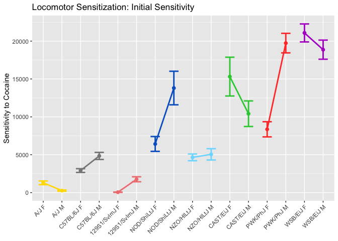

```r
sensi_summary = as.data.frame(sensi_summary)
sensi_summary$Strain_Sex = factor(sensi_summary$Strain_Sex,
                                  levels = paste(rep(founders_key$strain, each = 2), rep(c(" F", " M"), times = 8), sep = ""),
                                  ordered = TRUE)
sensi_summary$Strain = factor(sensi_summary$Strain,
                              levels = founders_key$strain,
                              ordered = TRUE)

sensi_strain_sex_plot = ggplot(data = sensi_summary, aes(x = Strain_Sex, y = Strain_Sex_mean, color = Strain, group = Strain)) +
  geom_line(size = 1) +
  geom_point(size = 2) +
  geom_errorbar(aes(ymin = Strain_Sex_ll, ymax = Strain_Sex_ul), width = 0.5, size = 1) +
  scale_color_manual(values = founders_key$collaborative_cross_color_broman) +
  theme(axis.text.x = element_text(angle = 45, hjust = 1), legend.position="none") +
  xlab(NULL) +
  ylab("Sensitivity to Cocaine") +
  ggtitle("Locomotor Sensitization: Initial Sensitivity")
sensi_strain_sex_plot
```

Plotting the strain:sex information for sham data.

```r
sensi_sham_summary = sensi_data %>%
  filter(Study == "SENS-SHAM") %>%
  group_by(Strain, Sex) %>%
  summarize(Strain_Sex_mean = mean(Sensi, na.rm = TRUE),
            Strain_Sex_sem = sd(Sensi, na.rm = TRUE) / length(which(!is.na(Sensi)))) %>%
  mutate(Strain_Sex = paste(Strain, gsub("^([MF]).*$", "\\1", Sex), sep = " "),
         Strain_Sex_ul = Strain_Sex_mean + Strain_Sex_sem,
         Strain_Sex_ll = Strain_Sex_mean - Strain_Sex_sem)
```

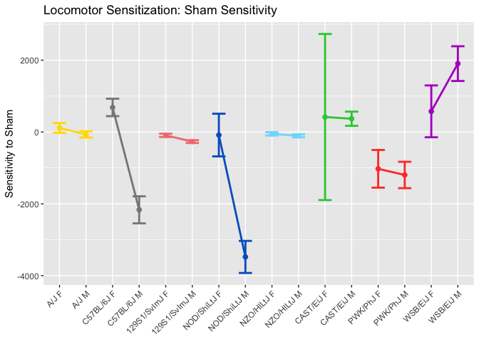

```r
sensi_sham_summary = as.data.frame(sensi_sham_summary)
sensi_sham_summary$Strain_Sex = factor(sensi_summary$Strain_Sex,
                                  levels = paste(rep(founders_key$strain, each = 2), rep(c(" F", " M"), times = 8), sep = ""),
                                  ordered = TRUE)
sensi_sham_summary$Strain = factor(sensi_summary$Strain,
                              levels = founders_key$strain,
                              ordered = TRUE)

sensi_strain_sex_sham_plot = ggplot(data = sensi_sham_summary, aes(x = Strain_Sex, y = Strain_Sex_mean, color = Strain, group = Strain)) +
  geom_line(size = 1) +
  geom_point(size = 2) +
  geom_errorbar(aes(ymin = Strain_Sex_ll, ymax = Strain_Sex_ul), width = 0.5, size = 1) +
  scale_color_manual(values = founders_key$collaborative_cross_color_broman) +
  theme(axis.text.x = element_text(angle = 45, hjust = 1), legend.position="none") +
  xlab(NULL) +
  ylab("Sensitivity to Sham") +
  ggtitle("Locomotor Sensitization: Sham Sensitivity")

sensi_strain_sex_sham_plot
```

Plotting raw sensitivity data

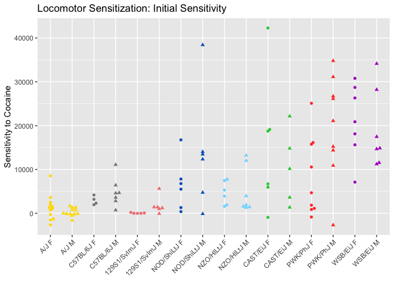

```r
sensi_data$Strain_Sex = factor(paste(sensi_data$Strain, gsub("^([MF]).*$", "\\1", sensi_data$Sex), sep = " "),
                               levels = levels(sensi_summary$Strain_Sex),
                               ordered = TRUE)
sensi_data$Strain = factor(sensi_data$Strain,
                           levels = founders_key$strain,
                           ordered = TRUE)
raw_data_plot = ggplot(data = sensi_data[which(sensi_data$Study == "SENS-COCA"),], aes(x = Strain_Sex, y = Sensi, color = Strain, shape = Sex)) +
  geom_beeswarm() +
  scale_color_manual(values = founders_key$collaborative_cross_color_broman) +
  theme(axis.text.x = element_text(angle = 45, hjust = 1), legend.position="none") +
  xlab(NULL) +
  ylab("Sensitivity to Cocaine") +
  ggtitle("Locomotor Sensitization: Initial Sensitivity")
raw_data_plot
```

Saving plot

```r
saveRDS(raw_data_plot, "./output/founders_sensitivity_raw_data_plot.RDS")
saveRDS(sensi_strain_sex_plot, "./output/founders_sensitivity_strain_sex_plot.RDS")
```

# 3 Reproducibility Information

## 3.1 Software Used

### 3.1.1 R session and OS information

```r
sensi_plot_sessionInfo
```

[output not shown]

```r
saveRDS(sensi_plot_sessionInfo, paste(script_root_dir, "./output/sensitivity_plot_sessionInfo_",current_date,".RDS", sep = ""), compress="xz")
```

## 3.2 Document Control

This document was prepared using RMarkdown in RStudio.